# Creating images with R

with a little bit of magick

Sheng-Jer Lin

```css
body {
  font-family: 'Cosmic Sans';
  background-color: #f5f5f5;
  color: #F8BBD0;
}

h2 {
  color: #CE93D8;
}

code {
  color: #B39DDB;
  background-color: #f9f2f4;
}
```

## Project requirements

Throughout this project, I have used GitHub to keep a clean record of my progress but also allowed me to revert to previous versions of my work when necessary.

Link to my GitHub repository: https://github.com/Dreamyturtles/stat220/blob/main/README.md

Below is a screenshot of the project folder in my local environment:

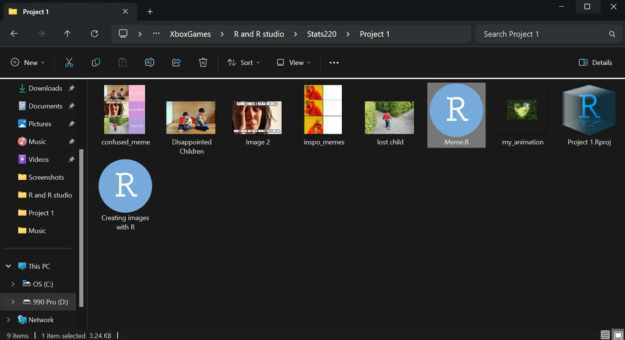

Screenshot

As you can see from the screenshot, I have set up and used .Rproject within RStudio shown with Project 1.Rproj file. All the files and images used for this project are organized and visible in the project directory of stats220 then all under project 1. As for the GitHub section, i’ve added the link for the repository which I have changed the name to stats220 and demonstrated markdown syntax (I’ve used #, ##, ### for different levels of headers and applied three ways to bullet point and written in bold and italics and added two links one to my professional page and one to my github page)

## My meme

[figure not shown]

Inspo_meme

The key components from the inspo meme changing the side three images by changing the website address and changing the right side white boxes on the side with words that is relatable to the right images i’ve applied similar layout accordingly with the frames, i’ve also applied a font and colour to the background and the text and added a font.

```r
#Load Packages to run functions

library(magick)

#Labelling the images into object values

Disappointed <- image_read("https://cdn.pixabay.com/photo/2020/05/20/05/43/offense-5194799_1280.jpg") %>%
  image_scale(750)

Meme_women <- image_read("https://static.wixstatic.com/media/f6bccd_27c5342e39874f3ba9727eb84ba91e3a~mv2.png/v1/fit/w_491%2Ch_326%2Cal_c%2Cq_80,enc_auto/file.jpg") %>%
  image_scale(750)

Lost_child <- image_read("https://cdn.pixabay.com/photo/2016/10/07/15/58/child-1721906_1280.jpg") %>%
  image_scale(750)

#Creating the right side text

first_text <- image_blank(width = 500,
                          height = 500,
                          color = "#F8BBD0") %>%
  image_annotate(text = "When you can't figure out\n what is wrong with the code",
                 color = "#FFFFFF",
                 size = 40,
                 font = "Comic Sans",
                 gravity = "center")

second_text <- image_blank(width = 500,
                         height = 500,
                         color = "#CE93D8") %>%
  image_annotate(text = "Social Media",
                 color = "#FFFFFF",
                 size = 80,
                 font = "Comic Sans",
                 gravity = "center")

third_text <- image_blank(width = 500,
                       height = 500,
                       color = "#B39DDB") %>%
  image_annotate(text = "Stats 220",
                 color = "#FFFFFF",
                 size = 80,
                 font = "Comic Sans",
                 gravity = "center")

# Create each image to text pair and flatten the image sequence
pair1 <- image_append(c(Disappointed, first_text), stack = FALSE) %>%
  image_scale("500x500") %>%
  image_flatten()
pair2 <- image_append(c(Meme_women, second_text), stack = FALSE) %>%
  image_scale("500x500") %>%
  image_flatten()
pair3 <- image_append(c(Lost_child, third_text), stack = FALSE) %>%
  image_scale("500x500") %>%
  image_flatten()

# Stack the pairs vertically
combined_image <- image_append(c(pair1, pair2, pair3), stack = TRUE)

# Write the combined image to a file
image_write(combined_image, "confused_meme.png")
```

```r
# creating a vector for the counts
counts <- 1 : 3 %>% as.character()
heart_image <- image_read("https://cdn.pixabay.com/photo/2016/02/10/21/57/heart-1192662_1280.jpg") %>%
  image_scale(500)

# creating each frame, where the text comes from the counts vector
frame1 <- heart_image %>%
  image_annotate(text = counts[3],color = "#F8BBD0", size = 100, gravity = "center") %>%
  image_scale(300) %>%
  image_extent("500x500")

frame2 <- heart_image %>%
  image_annotate(text = counts[2],color = "#CE93D8", size = 100, gravity = "center") %>%
  image_scale(400) %>%
  image_extent("500x500")

frame3 <- heart_image %>%
  image_annotate(text = counts[1],color = "#B39DDB", size = 100, gravity = "center") %>%
  image_scale(500) %>%
  image_extent("500x500")


# Create a list of frames for the animation
frames <- list(frame1, frame2, frame3, pair1, pair2, pair3)

# Add a transition effect between frames
frames <- lapply(frames, image_morph, frames = 0.5)

# Create the animation
animation <- image_animate(image_join(frames), fps = 0.5)

# Write the animation to a file
image_write(animation, "my_animation.gif")
```

## Creativity

For this project, I’ve tried to add functions based from the foundation functions in the magick package, for example by following the script of the image_annotate function and making adjustments to the sizing that meant how too fill in the white regions with colours and added HTML colours also by the ability to rearrange the boxes based on the vertical and horizontal axis changes the meaning of the meme itself with the stack functions of being TRUE or FALSE. By adding new functions like image_flatten to merge the layers together into a single layer to make the meme on one sheet.

For the Github repository, I’ve changed the the layout with three subheadings by utilizing the # functions and added links that incorporate the profile and professional profile

For the animation section I’ve made adjustments with the images to animate and added more frames to flow with the context of the meme by changing the starting frames by pairing two separate sets in and merging them together.

I’ve also added background design to the css and created font with colour and created a second heading with h2 elements

## Learning reflection

An important concept that I’ve learnt and practiced through HTML is how it functions with other coding languages like CSS and how it has the ability to create interactive webpages for enhancing the user experience. Since I previosuly imagined that each coding language has it’s own platform and just updates accordingly with new languages to learn about. As for data technology, I’m particularly interested and passionate about how UX designers visualizes to create canvas elements in 2D and 3D form and representing it by graphics to understand patterns also curious on how the other programming languages like Javascript and Python work as machine learning is gaining popularity and how these have the ability to produce code through live self driving vehicles and AI generated responses within seconds.